# DATA SCIENCE FOR INDUSTRY ASSIGNMENT 1

Author

Envoy Nzimba (NZMENV001)

Published

September 25, 2024

# PLAGIARISM DECLARATION

I, Envoy Nzimba , hereby declare that the work on which this assignment is based on my original work (except where acknowledgements indicate otherwise) and that neither the whole work nor any part of it has been, is being, or is to be submitted for another degree in this or any other university. I authorise the University to reproduce for the purpose of research either the whole or any portion of the contents in any manner whatsoever.

**Signature:** Envoy Nzimba **Date:** 25 September 2024

# BUILDING RECOMMENDER SYSTEM

## **INTRODUCTION**

The primary objective of this assignment is to develop a recommender system that can predict book ratings for both existing and new users, effectively addressing the cold-start problem by assuming new users will rate a small number of books upon joining the platform. The system will integrate three distinct approaches: item-based collaborative filtering (CF), user-based CF, and matrix factorization. By combining these methods into an ensemble, the aim is to leverage their individual strengths and ultimately achieving a more robust and accurate recommendation system. The assignment will detail the exploratory data analysis conducted to understand the dataset, the methodologies used to build the recommender systems and evaluating metrics used to assess the performance.

# EXPLORATORY DATA ANALYSIS

## **Loading data**

There are three datasets, namely Books, Ratings, and Users. The data was loaded, and appropriate joins were performed to create a combined dataset. Combining the datasets is essential as it consolidates relevant information from each source, allowing for a more comprehensive analysis. This approach ensures that user preferences, book details, and rating data are all available in a single structure, facilitating better feature extraction and improving the quality of recommendations.

## **Distribution of ratings**

A significant number of ratings are zeros as shown in the distribution below, which may suggest that users have read the book but did not provide a rating..

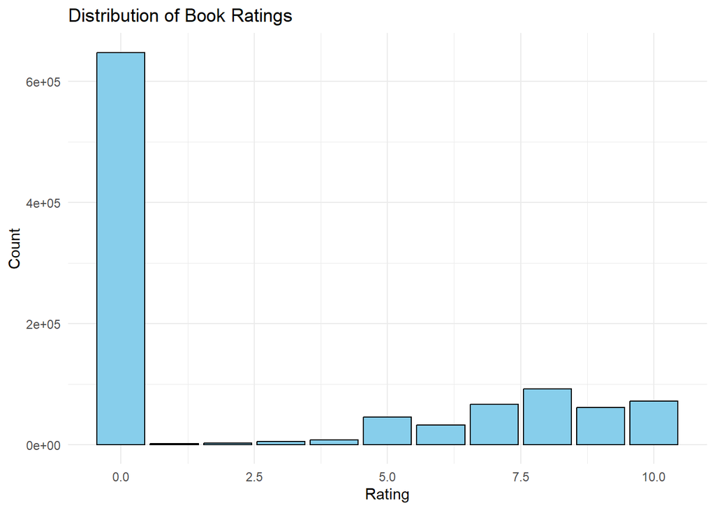

Books with zero ratings do not provide any feedback from users. Since recommendation systems rely heavily on user-item interactions (such as ratings), items with no ratings cannot help the model learn meaningful patterns or preferences. Including them in the model would not contribute to making useful predictions. Therefore, removing these books ensures that the model focuses only on books that have been rated, leading to cleaner data and potentially more accurate recommendations. Below is the distribution of book ratings after removing books with zero ratings.

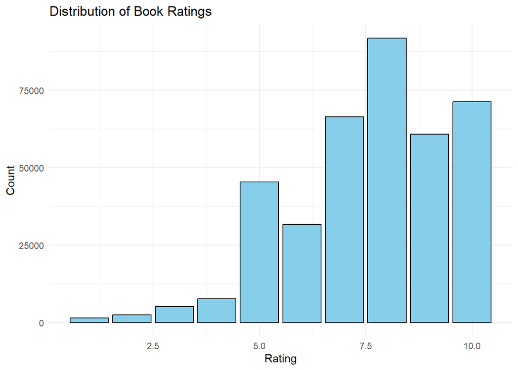

## **Top Ten rated books**

An analysis of the top 10 rated books shows that, on average, these books have received over 300 ratings each. This indicates their broad popularity and engagement among users. Books with a high number of ratings tend to be well-known, widely circulated and potentially influenced in shaping reading trends within the dataset.

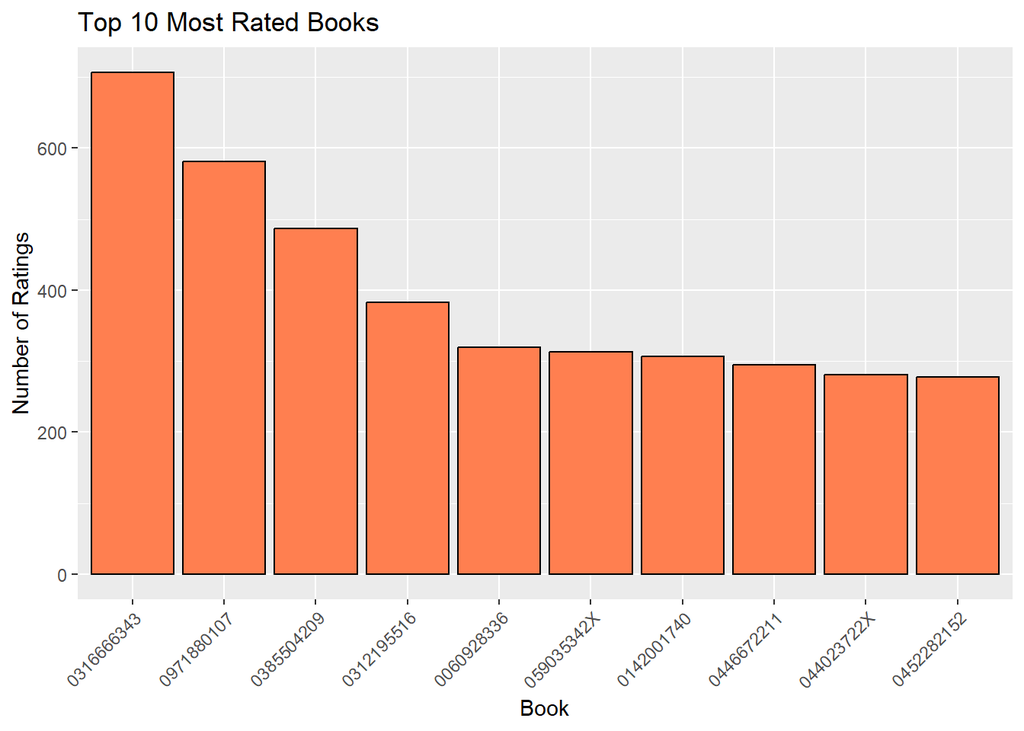

## **Creating Subset data to work with**

Working with a large dataset where many users or items have minimal ratings can significantly increase computational complexity. To enhance the effectiveness and reliability of the recommendations system, specific refinements were made to the dataset. These refinements includes selecting users with more than 300 ratings and books that received more than 200 ratings. By selecting users who have provided more than 300 ratings, the analysis prioritizes those who are highly engaged with the system. Filtering books with high ratings ensures that the recommender system is based on books with significant feedback. The filtered data is shown in the table below.

Filtered Data

| User.ID | ISBN | Book_Title | Book.Rating |
| --- | --- | --- | --- |
| 7346 | 0786868716 | The Five People You Meet in Heaven , 2003 | 7 |
| 11676 | 0156027321 | Life of Pi , 2003 | 6 |
| 11676 | 0312195516 | The Red Tent (Bestselling Backlist) , 1998 | 10 |
| 11676 | 0312278586 | The Nanny Diaries: A Novel , 2002 | 6 |
| 11676 | 0316666343 | The Lovely Bones: A Novel , 2002 | 5 |

# **BOOK RECOMMENDATIONS SYSTEMS**

## **1. USER-BASED COLLABORATIVE FILTERING**

User-based collaborative filtering predicts a user’s preferences by finding other users with similar tastes and recommending items that those similar users have liked Schafer et al. (2007) . Firstly, the dataset was transformed into matrix format. This matrix facilitates the representation of user preferences for various books, where rows correspond to users, columns correspond to books and the entries indicate the ratings given by users. The reason of doing this is because it becomes possible to apply collaborative filtering techniques for recommendation and analyze user preferences and behaviors more effectively.

### **Model function**

A cosine similarity function is used to measure how similar two users are based on their rating patterns Schafer et al. (2007) . The dataset was transformed into a matrix where rows represent users, column represents books, and entries are ratings. The cosines similarity between the target user and all other users was computed to find those with similar rating patterns. Books that the target user has not yet read but have been highly rated by similar user are recommended.

### **Recommending Existing Users**

The recommendation system produced a list of the top 5 book recommendations for the user with ID “11676”. This output suggests that the recommended books are well-regarded by similar users, with the highest-rated books being more likely to align with the user’s preferences.

Existing User Recommendations

| ISBN | count | avg_rating |
| --- | --- | --- |
| 0142001740 | 3 | 9.000000 |
| 043935806X | 2 | 9.000000 |
| 0060928336 | 3 | 8.333333 |
| 0316769487 | 3 | 8.333333 |
| 0060930535 | 2 | 6.500000 |

### **Recommending New Users**

The recommendations reflect books that are generally well-rated by users with similar preferences, providing a curated list that aligns with the new user’s rating patterns. The input consisted of ratings for five books, with scores ranging from 2 to 5. Using these ratings, the recommendation function produces a list of books with their respective average ratings. The table below shows books recommended to a new user based on the preferences of other users who are similar to them. Books with higher average ratings (like ISBN=“`0312195516"` with a rating of 4.6) are recommended more strongly because the model predicts the user would rate them higher.

New User Recommendations

| ISBN | avg_rating |
| --- | --- |
| 0312195516 | 4.6 |
| 0316666343 | 3.6 |
| 059035342X | 3.5 |
| 0156027321 | 3.4 |
| 0743418174 | 3.2 |

## **2. ITEM-BASED COLLABORATIVE FILTERING**

The item-based recommendation focuses on the relationship between items rather than users Ekstrand, Riedl, and Konstan (2011) . Unlike user-based collaborative filtering, which calculates the similarity between users, item-based collaborative filtering measures the similarity between items. Below is the item user matrix used.

Item-User Matrix

|  | 7346 | 11676 | 16634 | 16795 | 23872 | 23902 | 30276 | 31315 |
| --- | --- | --- | --- | --- | --- | --- | --- | --- |
| 0060928336 | 0 | 0 | 0 | 0 | 0 | 0 | 0 | 0 |
| 0060930535 | 0 | 0 | 0 | 4 | 0 | 0 | 0 | 0 |
| 0142001740 | 0 | 0 | 0 | 10 | 0 | 0 | 0 | 0 |
| 0156027321 | 0 | 6 | 0 | 0 | 0 | 0 | 0 | 0 |
| 0312195516 | 0 | 10 | 0 | 9 | 0 | 0 | 0 | 0 |
| 0312278586 | 0 | 6 | 0 | 0 | 0 | 0 | 0 | 0 |
| 0316601950 | 0 | 0 | 0 | 0 | 0 | 0 | 6 | 0 |
| 0316666343 | 0 | 5 | 0 | 10 | 0 | 0 | 0 | 0 |

### **Model function**

The model implementation includes a function to compute cosine similarity between book rating vectors and another function to generate recommendations based on the similarity of a specified book to all other books. The recommendation function identifies and ranks books similar to the given book, providing a list of the top recommendations based on similarity scores.

### **Recommending Existing Users**

In testing the recommender system, a book with the ID “0312195516” was selected for evaluation. Using the item-based collaborative filtering approach, recommendations were generated based on the similarity of this book to other books in the dataset. The top five recommended books, along with their similarity scores, were identified

Existing Users Recommendation

| ISBN | similarity |
| --- | --- |
| 067976402X | 0.4108213 |
| 0312195516 | 0.3916678 |
| 0971880107 | 0.3906357 |
| 0316666343 | 0.3705316 |
| 0060928336 | 0.3606295 |

**Visualizing recommended books**

These recommendations highlight books that are most similar to the specified book, providing relevant suggestions based on item-based collaborative filtering.

[figure not shown]

### **Recommending New Users**

A new user’s ratings were used to generate book recommendations. Recommendations were generated by computing the similarity between the new user’s ratings and all other items in the matrix, excluding books the new user has already rated. The top recommended books were then identified based on similarity scores.

New Users Recommendation

| ISBN | similarity |
| --- | --- |
| 0345337662 | 0.3778179 |
| 0060928336 | 0.3456885 |
| 0316769487 | 0.2627400 |
| 0743418174 | 0.2580729 |
| 0312278586 | 0.2543691 |

These recommendations represent books that are most similar to those rated by the new user, providing relevant suggestions based on the item-based collaborative filtering approach.

[figure not shown]

# **3. MATRIX FACTORIZATION**

## **Training the model**

### **Without Regularization**

The recommendation model was trained using the `recosystem` package without applying regularization. The dataset was used, and the model was set to 20 latent dimensions with a learning rate of 0.1.

```
iter      tr_rmse          obj
   0       5.7145   1.0444e+07
   1       3.4686   4.1513e+06
   2       2.5312   2.4516e+06
   3       2.0089   1.7393e+06
   4       1.6465   1.3443e+06
   5       1.3843   1.1102e+06
   6       1.1925   9.6539e+05
   7       1.0524   8.7454e+05
   8       0.9474   8.1494e+05
   9       0.8665   7.7368e+05
  10       0.8010   7.4388e+05
  11       0.7466   7.2087e+05
  12       0.7003   7.0225e+05
  13       0.6612   6.8780e+05
  14       0.6267   6.7538e+05
  15       0.5974   6.6575e+05
  16       0.5715   6.5720e+05
  17       0.5491   6.5047e+05
  18       0.5290   6.4425e+05
  19       0.5115   6.3900e+05
```

### **With Regularization**

The `recosystem` model was trained using regularization to prevent overfitting. Regularization parameters were set at cost_P1=0.1 for users and cost_q1=0.1,for items, striking a balance between fitting the data and maintaining generalization. The latent dimension was set to 20, with a learning rate of 0.1. These regularization values were selected to smooth the model’s predictions and ensure it handles sparse data effectively, avoiding overly specific patterns that may not generalize well to new data.

```
iter      tr_rmse          obj
   0       5.2014   9.4315e+06
   1       2.9780   3.8778e+06
   2       2.2479   2.7378e+06
   3       1.8359   2.2349e+06
   4       1.5580   1.9550e+06
   5       1.3649   1.7889e+06
   6       1.2297   1.6854e+06
   7       1.1345   1.6198e+06
   8       1.0655   1.5758e+06
   9       1.0123   1.5434e+06
  10       0.9695   1.5194e+06
  11       0.9331   1.5002e+06
  12       0.8999   1.4827e+06
  13       0.8705   1.4678e+06
  14       0.8434   1.4552e+06
  15       0.8180   1.4435e+06
  16       0.7946   1.4331e+06
  17       0.7727   1.4242e+06
  18       0.7512   1.4149e+06
  19       0.7316   1.4070e+06
```

## **Model Evaluation**

### **Without Regularization**

The model was tested on a separate test dataset using the model trained without regularization. Predictions were generated and thepredicted ratings were then compared with the actual ratings in the test dataset, and the Root Mean Square Error (RMSE) was computed as 2.305. This RMSE value indicates the accuracy of the model without regularization, highlighting the average prediction error when comparing the predicted and actual ratings.

```
prediction output generated at predictions_test_without_reg.txt
```

```
[1] "RMSE on the test set without regularization: 2.30523809876121"
```

### **With Regularization**

The model was tested on the same test dataset but using the version trained with regularization. The predicted ratings were generated and these were compared with the actual ratings in the test dataset. The Root Mean Square Error (RMSE) for this model was computed as 2.307, which is nearly identical to the RMSE without regularization. This shows that regularization had little impact on the prediction accuracy in this case.

```
prediction output generated at predictions_test_with_reg.txt
```

```
[1] "RMSE on the test set with regularization: 2.30743650289921"
```

### **Generating Predictions for Users with and without Regularization**

```
prediction output generated at predictions_unrated_books_without_reg.txt
```

```
prediction output generated at predictions_unrated_books_with_reg.txt
```

Matrix Factorization Recommended Books

| User.ID | ISBN | Predicted.Rating_Without_Reg | Predicted.Rating_With_Reg | Book_Title |
| --- | --- | --- | --- | --- |
| 11676 | 0786868716 | 7.62573 | 7.62573 | The Five People You Meet in Heaven , 2003 |
| 11676 | 0156027321 | 7.62573 | 7.62573 | Life of Pi , 2003 |
| 11676 | 0312195516 | 7.62573 | 7.62573 | The Red Tent (Bestselling Backlist) , 1998 |
| 11676 | 0312278586 | 7.62573 | 7.62573 | The Nanny Diaries: A Novel , 2002 |
| 11676 | 0316666343 | 7.62573 | 7.62573 | The Lovely Bones: A Novel , 2002 |

# **Final Ensembled Model: Generating Recommendations**

The ensemble model (for existing users ) was constructed by merging user-based, item-based, and matrix factorization recommendations into a single dataframe. Weighted averaging was then used, with assumed assigned weights (User-Based: 0.3, Item-Based: 0.4, Matrix Factorization: 0.3) to compute final ensemble ratings for each book. Item-based recommendations was given a higher weight because they tend to capture item similarities more effectively, which often translates into more relevant and accurate recommendations. Books were ranked according to these ensemble ratings, yielding a prioritized list of top recommendations.

The highest-rated books based on the ensemble model are *The Secret Life of Bees* and *Harry Potter and the Order of the Phoenix*, both with an ensemble rating of 2.7as as shown in the visualization below**.** The ensembled model effectively integrates recommendations from user-based, item-based, and matrix factorization approaches to provide a balanced set of top books for recommendation.

Ensembled Model Recommended Books

| ISBN | ensemble_rating | Book_Title |
| --- | --- | --- |
| 0142001740 | 2.700000 | The Secret Life of Bees , 2003 |
| 043935806X | 2.700000 | Harry Potter and the Order of the Phoenix (Book 5) , 2003 |
| 0060928336 | 2.644252 | Divine Secrets of the Ya-Ya Sisterhood: A Novel , 1997 |
| 0316769487 | 2.500000 | The Catcher in the Rye , 1991 |
| 0312195516 | 2.444386 | The Red Tent (Bestselling Backlist) , 1998 |

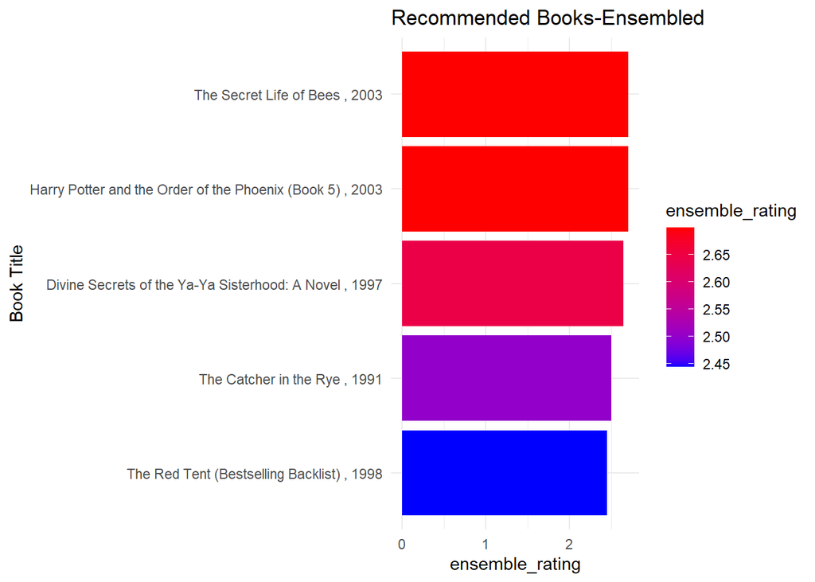

## References

Ekstrand, M. D., J. T. Riedl, and J. A. Konstan. 2011. “Collaborative Filtering Recommender Systems.” *Foundations and Trends in Human–Computer Interaction* 4 (2): 81–173.

Kangas, S. 2002. *Collaborative Filtering and Recommendation Systems*. VTT information technology.

Schafer, J. B., D. Frankowski, J. Herlocker, and S. Sen. 2007. “Collaborative Filtering Recommender Systems.” In *The Adaptive Web: Methods and Strategies of Web Personalization*, 291–324. Springer Berlin Heidelberg.